# R Intermediário - MQuinho 2021

Rômulo Damasceno

30/10/2021

## 1. Alinhamento preliminar

### 1.1. O processo/workflow da Ciência de Dados

O mundo da análise de dados consiste em uma gama de processos interdependentes que nos permite sair de uma dado bruto, por vezes bastante bagunçado, até chegarmos nas informações propriamente ditas, sendo estas últimas o produto final, capaz de gerar valor para as pessoas e para as organizações.

Um dos maiores problemas enfrentados por nós é o tratamento e a limpeza desses dados. É comum, por exemplo, recebermos dados com erros de digitação, com múltiplas informações numa mesma célula, dados de uma mesma natureza em planilhas separadas, enfim, as possibilidades do caos são infinitas.

No curso de R para análise de dados passamos por cada um dos tópicos, sem nos aprofundar na parte de “data tidying”, e é o nosso principal interesse neste curso, para além da criação de funções.

### 1.2. A iniciativa tidyverse

[figure not shown]

### 1.3. Quais os pacotes que usaremos neste curso?

**dplyr e tidyr:**

São os pacotes responsáveis (especialmente o dplyr) pelos procedimentos de query, manipulação de bancos de dados, seleção de colunas, filtragens por condições, reordenamento do banco de dados por condições, criação de novas variáveis, produção de estatísticas síntese, etc. Muito do nosso trabalho é feito aqui!

A principal função do tidyr é alterar estruturalmente os dataframes resultantes das funções do dplyr, transformando colunas em linhas, linhas em colunas, unindo-as ou separando-as. São funções bastante úteis ao manipular o dado para criar tabelas ou fazer operações com dataframes.

**ggplot2:**

Um dos pacotes mais importantes do tidyverse, o ggplot é capaz de produzir gráficos altamente customizáveis e bastante profissionais. É uma das ferramentas mais competentes disponíveis e mais largamente utilizadas para a função atualmente.

**stringr:**

A principal função do stringr é facilitar o trabalho com variáveis textuais despadronizadas (a resposta de uma pergunta aberta de um questionário por exemplo). O stringr é capaz de reconhecer padrões textuais e executar diversos tipos de transformações com eles.

**purrr:**

Utilizado para replicar procedimentos feitos em um vetor, para múltiplos vetores. É um grande aliado para evitar a repetição de código e poupa muito tempo de trabalho.

## 2. Revisão - dplyr e as funções básicas de manipulação de bancos de dados

O dplyr é um dos pacotes mais importantes do tidyverse, pois condensa várias funções que precisam ser utilizadas constantemente no processo de análise de dados, como seleção de colunas, filtragem de casos, recodificações de variáveis em outras, etc. Tais operações são feitas com 5 verbos principais:

- `filter()` : Filtra as observações por uma ou várias condições.
- `arrange()` : Reordena as linhas com base numa coluna de referência.
- `select()` : Seleciona as colunas desejadas.
- `mutate()` : Cria novas variáveis que são funções de variáveis pré-existentes.
- `summarise()` : Collapse many values down to a single summary.

```r
# Banco de dados genérico, contido dentro do tidyverse
USArrests
```

```
##                Murder Assault UrbanPop Rape
## Alabama          13.2     236       58 21.2
## Alaska           10.0     263       48 44.5
## Arizona           8.1     294       80 31.0
## Arkansas          8.8     190       50 19.5
## California        9.0     276       91 40.6
## Colorado          7.9     204       78 38.7
## Connecticut       3.3     110       77 11.1
## Delaware          5.9     238       72 15.8
## Florida          15.4     335       80 31.9
## Georgia          17.4     211       60 25.8
## Hawaii            5.3      46       83 20.2
## Idaho             2.6     120       54 14.2
## Illinois         10.4     249       83 24.0
## Indiana           7.2     113       65 21.0
## Iowa              2.2      56       57 11.3
## Kansas            6.0     115       66 18.0
## Kentucky          9.7     109       52 16.3
## Louisiana        15.4     249       66 22.2
## Maine             2.1      83       51  7.8
## Maryland         11.3     300       67 27.8
## Massachusetts     4.4     149       85 16.3
## Michigan         12.1     255       74 35.1
## Minnesota         2.7      72       66 14.9
## Mississippi      16.1     259       44 17.1
## Missouri          9.0     178       70 28.2
## Montana           6.0     109       53 16.4
## Nebraska          4.3     102       62 16.5
## Nevada           12.2     252       81 46.0
## New Hampshire     2.1      57       56  9.5
## New Jersey        7.4     159       89 18.8
## New Mexico       11.4     285       70 32.1
## New York         11.1     254       86 26.1
## North Carolina   13.0     337       45 16.1
## North Dakota      0.8      45       44  7.3
## Ohio              7.3     120       75 21.4
## Oklahoma          6.6     151       68 20.0
## Oregon            4.9     159       67 29.3
## Pennsylvania      6.3     106       72 14.9
## Rhode Island      3.4     174       87  8.3
## South Carolina   14.4     279       48 22.5
## South Dakota      3.8      86       45 12.8
## Tennessee        13.2     188       59 26.9
## Texas            12.7     201       80 25.5
## Utah              3.2     120       80 22.9
## Vermont           2.2      48       32 11.2
## Virginia          8.5     156       63 20.7
## Washington        4.0     145       73 26.2
## West Virginia     5.7      81       39  9.3
## Wisconsin         2.6      53       66 10.8
## Wyoming           6.8     161       60 15.6
```

```r
# select
USArrests %>%
  select(Murder, Assault)
```

```
##                Murder Assault
## Alabama          13.2     236
## Alaska           10.0     263
## Arizona           8.1     294
## Arkansas          8.8     190
## California        9.0     276
## Colorado          7.9     204
## Connecticut       3.3     110
## Delaware          5.9     238
## Florida          15.4     335
## Georgia          17.4     211
## Hawaii            5.3      46
## Idaho             2.6     120
## Illinois         10.4     249
## Indiana           7.2     113
## Iowa              2.2      56
## Kansas            6.0     115
## Kentucky          9.7     109
## Louisiana        15.4     249
## Maine             2.1      83
## Maryland         11.3     300
## Massachusetts     4.4     149
## Michigan         12.1     255
## Minnesota         2.7      72
## Mississippi      16.1     259
## Missouri          9.0     178
## Montana           6.0     109
## Nebraska          4.3     102
## Nevada           12.2     252
## New Hampshire     2.1      57
## New Jersey        7.4     159
## New Mexico       11.4     285
## New York         11.1     254
## North Carolina   13.0     337
## North Dakota      0.8      45
## Ohio              7.3     120
## Oklahoma          6.6     151
## Oregon            4.9     159
## Pennsylvania      6.3     106
## Rhode Island      3.4     174
## South Carolina   14.4     279
## South Dakota      3.8      86
## Tennessee        13.2     188
## Texas            12.7     201
## Utah              3.2     120
## Vermont           2.2      48
## Virginia          8.5     156
## Washington        4.0     145
## West Virginia     5.7      81
## Wisconsin         2.6      53
## Wyoming           6.8     161
```

```r
# filter
USArrests %>%
  filter(Murder < 10 & Assault >= 200)
```

```
##            Murder Assault UrbanPop Rape
## Arizona       8.1     294       80 31.0
## California    9.0     276       91 40.6
## Colorado      7.9     204       78 38.7
## Delaware      5.9     238       72 15.8
```

```r
# mutate

media_homicidios <- mean(USArrests$Murder)

recodes_USArrests<- USArrests %>%
  mutate(homicidio_cat = case_when(Murder > media_homicidios ~ 'Acima da média',
                                   Murder < media_homicidios ~ 'Abaixo da média'))

# arrange
recodes_USArrests %>%
  arrange(-Murder)
```

```
##                Murder Assault UrbanPop Rape   homicidio_cat
## Georgia          17.4     211       60 25.8  Acima da média
## Mississippi      16.1     259       44 17.1  Acima da média
## Florida          15.4     335       80 31.9  Acima da média
## Louisiana        15.4     249       66 22.2  Acima da média
## South Carolina   14.4     279       48 22.5  Acima da média
## Alabama          13.2     236       58 21.2  Acima da média
## Tennessee        13.2     188       59 26.9  Acima da média
## North Carolina   13.0     337       45 16.1  Acima da média
## Texas            12.7     201       80 25.5  Acima da média
## Nevada           12.2     252       81 46.0  Acima da média
## Michigan         12.1     255       74 35.1  Acima da média
## New Mexico       11.4     285       70 32.1  Acima da média
## Maryland         11.3     300       67 27.8  Acima da média
## New York         11.1     254       86 26.1  Acima da média
## Illinois         10.4     249       83 24.0  Acima da média
## Alaska           10.0     263       48 44.5  Acima da média
## Kentucky          9.7     109       52 16.3  Acima da média
## California        9.0     276       91 40.6  Acima da média
## Missouri          9.0     178       70 28.2  Acima da média
## Arkansas          8.8     190       50 19.5  Acima da média
## Virginia          8.5     156       63 20.7  Acima da média
## Arizona           8.1     294       80 31.0  Acima da média
## Colorado          7.9     204       78 38.7  Acima da média
## New Jersey        7.4     159       89 18.8 Abaixo da média
## Ohio              7.3     120       75 21.4 Abaixo da média
## Indiana           7.2     113       65 21.0 Abaixo da média
## Wyoming           6.8     161       60 15.6 Abaixo da média
## Oklahoma          6.6     151       68 20.0 Abaixo da média
## Pennsylvania      6.3     106       72 14.9 Abaixo da média
## Kansas            6.0     115       66 18.0 Abaixo da média
## Montana           6.0     109       53 16.4 Abaixo da média
## Delaware          5.9     238       72 15.8 Abaixo da média
## West Virginia     5.7      81       39  9.3 Abaixo da média
## Hawaii            5.3      46       83 20.2 Abaixo da média
## Oregon            4.9     159       67 29.3 Abaixo da média
## Massachusetts     4.4     149       85 16.3 Abaixo da média
## Nebraska          4.3     102       62 16.5 Abaixo da média
## Washington        4.0     145       73 26.2 Abaixo da média
## South Dakota      3.8      86       45 12.8 Abaixo da média
## Rhode Island      3.4     174       87  8.3 Abaixo da média
## Connecticut       3.3     110       77 11.1 Abaixo da média
## Utah              3.2     120       80 22.9 Abaixo da média
## Minnesota         2.7      72       66 14.9 Abaixo da média
## Idaho             2.6     120       54 14.2 Abaixo da média
## Wisconsin         2.6      53       66 10.8 Abaixo da média
## Iowa              2.2      56       57 11.3 Abaixo da média
## Vermont           2.2      48       32 11.2 Abaixo da média
## Maine             2.1      83       51  7.8 Abaixo da média
## New Hampshire     2.1      57       56  9.5 Abaixo da média
## North Dakota      0.8      45       44  7.3 Abaixo da média
```

```r
# group by + summarise
recodes_USArrests %>%
  group_by(homicidio_cat) %>%
  summarise(media_assault_hom = mean(Assault),
            sd_assault_hom = sd(Assault),
            median_assault_hom = median(Assault))
```

```
## # A tibble: 2 x 4
##   homicidio_cat   media_assault_hom sd_assault_hom median_assault_hom
##   <chr>                       <dbl>          <dbl>              <int>
## 1 Abaixo da média              110.           47.0                110
## 2 Acima da média               242.           55.7                252
```

### 2.1. Variação ACROSS(), mutate_if() e mutate_all()

O across pode ser utilizado especialmente junto ao filter, mutate e summarise para realizar as operações em múltiplas colunas ao mesmo tempo.

```r
# Filter
USArrests %>%
  filter(across(.cols = 1:3) >= 10)
```

```
##                Murder Assault UrbanPop Rape
## Alabama          13.2     236       58 21.2
## Alaska           10.0     263       48 44.5
## Florida          15.4     335       80 31.9
## Georgia          17.4     211       60 25.8
## Illinois         10.4     249       83 24.0
## Louisiana        15.4     249       66 22.2
## Maryland         11.3     300       67 27.8
## Michigan         12.1     255       74 35.1
## Mississippi      16.1     259       44 17.1
## Nevada           12.2     252       81 46.0
## New Mexico       11.4     285       70 32.1
## New York         11.1     254       86 26.1
## North Carolina   13.0     337       45 16.1
## South Carolina   14.4     279       48 22.5
## Tennessee        13.2     188       59 26.9
## Texas            12.7     201       80 25.5
```

```r
# Mutate
class(USArrests$Murder)
```

```
## [1] "numeric"
```

```r
# Caso do mutate
USArrests %>%
  mutate(across(.cols = c('Murder', 'Assault'), .fns = as.double))
```

```
##                Murder Assault UrbanPop Rape
## Alabama          13.2     236       58 21.2
## Alaska           10.0     263       48 44.5
## Arizona           8.1     294       80 31.0
## Arkansas          8.8     190       50 19.5
## California        9.0     276       91 40.6
## Colorado          7.9     204       78 38.7
## Connecticut       3.3     110       77 11.1
## Delaware          5.9     238       72 15.8
## Florida          15.4     335       80 31.9
## Georgia          17.4     211       60 25.8
## Hawaii            5.3      46       83 20.2
## Idaho             2.6     120       54 14.2
## Illinois         10.4     249       83 24.0
## Indiana           7.2     113       65 21.0
## Iowa              2.2      56       57 11.3
## Kansas            6.0     115       66 18.0
## Kentucky          9.7     109       52 16.3
## Louisiana        15.4     249       66 22.2
## Maine             2.1      83       51  7.8
## Maryland         11.3     300       67 27.8
## Massachusetts     4.4     149       85 16.3
## Michigan         12.1     255       74 35.1
## Minnesota         2.7      72       66 14.9
## Mississippi      16.1     259       44 17.1
## Missouri          9.0     178       70 28.2
## Montana           6.0     109       53 16.4
## Nebraska          4.3     102       62 16.5
## Nevada           12.2     252       81 46.0
## New Hampshire     2.1      57       56  9.5
## New Jersey        7.4     159       89 18.8
## New Mexico       11.4     285       70 32.1
## New York         11.1     254       86 26.1
## North Carolina   13.0     337       45 16.1
## North Dakota      0.8      45       44  7.3
## Ohio              7.3     120       75 21.4
## Oklahoma          6.6     151       68 20.0
## Oregon            4.9     159       67 29.3
## Pennsylvania      6.3     106       72 14.9
## Rhode Island      3.4     174       87  8.3
## South Carolina   14.4     279       48 22.5
## South Dakota      3.8      86       45 12.8
## Tennessee        13.2     188       59 26.9
## Texas            12.7     201       80 25.5
## Utah              3.2     120       80 22.9
## Vermont           2.2      48       32 11.2
## Virginia          8.5     156       63 20.7
## Washington        4.0     145       73 26.2
## West Virginia     5.7      81       39  9.3
## Wisconsin         2.6      53       66 10.8
## Wyoming           6.8     161       60 15.6
```

```r
# mutate_if

recode_rapido <- USArrests %>%
  mutate_if(is.numeric, as.factor)

class(recode_rapido$UrbanPop)
```

```
## [1] "factor"
```

```r
# mutate_all
recode_rapido2 <- mpg %>%
  mutate_all(as.character)

class(recode_rapido2$drv)
```

```
## [1] "character"
```

## 3. Revisão - ggplot e construção de gráficos

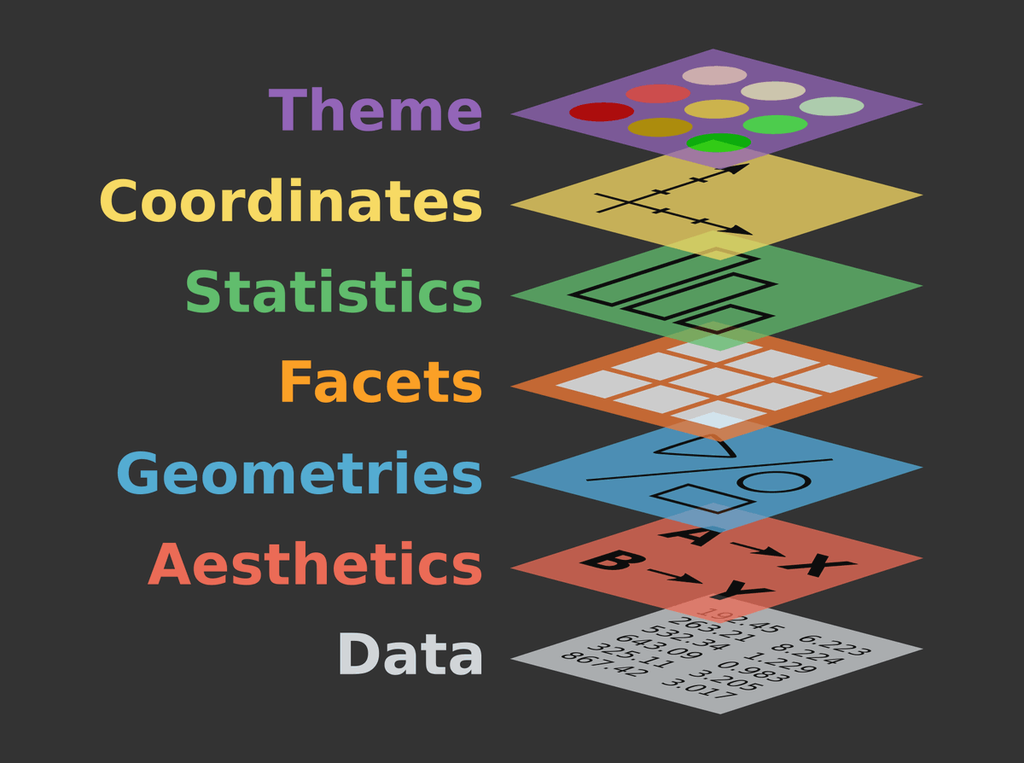

**The Grammar of Graphics - livro por Wilkinson**

O ggplot2 é baseado na gramática dos gráficos, a ideia de que é possível construir qualquer tipo de gráfico a partir dos mesmos componentes: Um banco de dados, um sistema de coordenadas e um geom isto é, uma forma geométrica que é capaz de representar visualmente os dados.

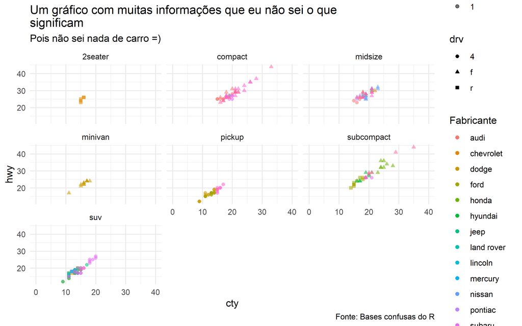

```r
mpg %>%                                             # Data
  ggplot(mapping = aes(x = cty,                     # Aesthetics 1 (X)
                       y = hwy,                     # Aesthetics 2 (Y)
                       colour = manufacturer,       # Aesthetics 3 (Colour)
                       shape = drv,                 # Aesthetics 4 (Shape)
                       alpha = 1)) +                # Asthetics 5 (Alpha)
  geom_point() +                                    # Geometries, Statistics
  facet_wrap(~ class) +                             # Facets
  xlim(0,40) +                                      # Coordinates
  labs(title = 'Um gráfico com muitas informações que eu não sei o que
significam',
       subtitle = 'Pois não sei nada de carro =)',
       caption = 'Fonte: Bases confusas do R',
       y = 'hwy',
       x = 'cty',
       colour = 'Fabricante') +                      # Labels
  theme_minimal()                                    # Theme
```

### 3.1. Barras

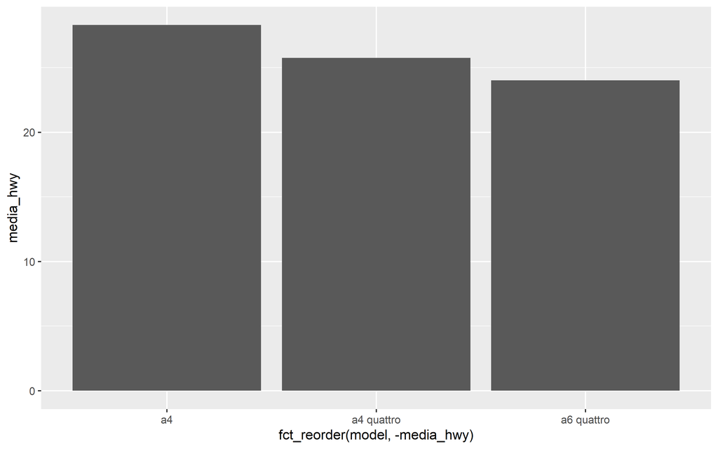

```r
# A estrutura básica de um gráfico de barras

mpg %>%
  filter(manufacturer == 'audi') %>%
  group_by(model) %>%
  summarise(media_hwy = mean(hwy)) %>%
  ggplot(mapping = aes(x = fct_reorder(model, -media_hwy),
                       y = media_hwy)) +
  geom_col()
```

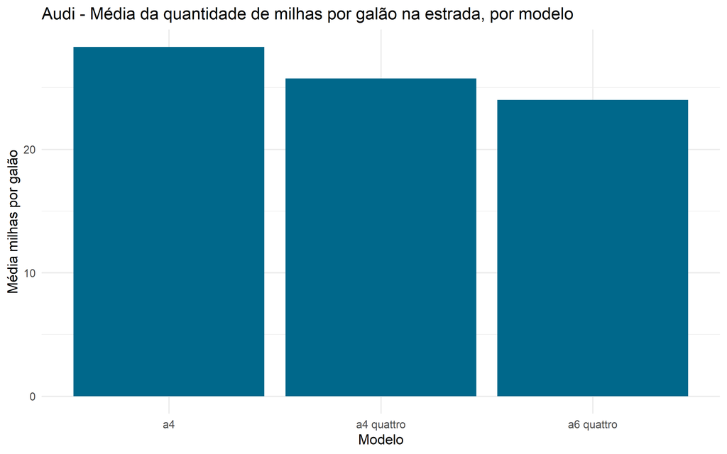

```r
# Melhoramento do storytelling - estética e interpretação

mpg %>%
  filter(manufacturer == 'audi') %>%
  group_by(model) %>%
  summarise(media_hwy = mean(hwy)) %>%
  ggplot(mapping = aes(x = fct_reorder(model, -media_hwy),
                       y = media_hwy)) +
  geom_col(fill = 'deepskyblue4') +
  labs(title = 'Audi - Média da quantidade de milhas por galão na estrada, por modelo',
       y = 'Média milhas por galão',
       x = 'Modelo') +
  theme_minimal()
```

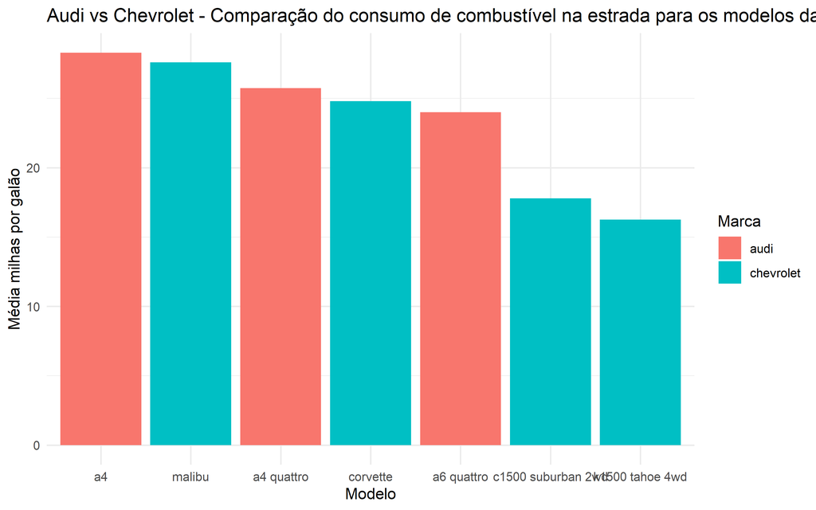

```r
# Comparação dos modelos de duas marcas, audi e chevrolet

mpg %>%
  filter(manufacturer %in% c('audi', 'chevrolet')) %>%
  group_by(manufacturer,model) %>%
  summarise(mean_model_manuf_hwy = mean(hwy)) %>%
  ggplot(mapping = aes(x = fct_reorder(model, -mean_model_manuf_hwy),
                       y = mean_model_manuf_hwy,
                       fill = manufacturer)) +
  geom_col(position = 'dodge') +
  labs(title = 'Audi vs Chevrolet - Comparação do consumo de combustível na estrada para os modelos das marcas',
       y = 'Média milhas por galão',
       x = 'Modelo',
       fill = 'Marca') +
  theme_minimal()
```

### 3.2. Histogramas e gráficos de densidade

```r
unique(mpg$manufacturer)
```

```
##  [1] "audi"       "chevrolet"  "dodge"      "ford"       "honda"
##  [6] "hyundai"    "jeep"       "land rover" "lincoln"    "mercury"
## [11] "nissan"     "pontiac"    "subaru"     "toyota"     "volkswagen"
```

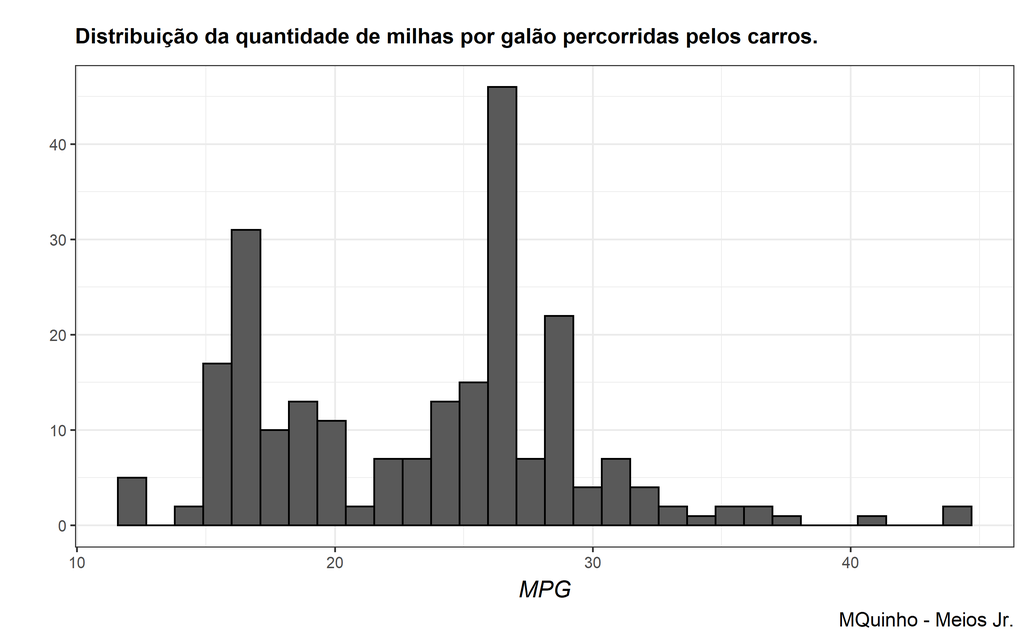

```r
# Histograma
mpg %>%
  ggplot(mapping = aes(x = hwy)) +
  geom_histogram(colour = 'black') +
  theme_bw() +
  labs(title = 'Distribuição da quantidade de milhas por galão percorridas pelos carros.',
       y = '',
       x = 'MPG',
       caption = "MQuinho - Meios Jr.") +
  theme(plot.title = element_text(face = "bold",
                                  margin = margin(10, 0, 10, 0),
                                  size = 12),
        axis.title.x = element_text(margin = margin(t = 5),
                                    size = 13,
                                    face = 'italic'),
        axis.title.y = element_text(margin = margin(r = 10),
                                    size = 13,
                                    face = 'italic'),
        plot.caption = element_text(size = 11))
```

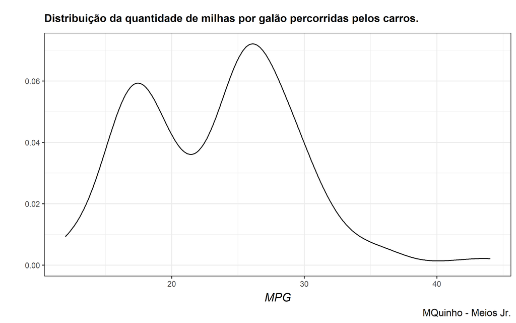

```r
# Gráfico de densidade

mpg %>%
  ggplot(mapping = aes(x = hwy)) +
  geom_density() +
  theme_bw() +
  labs(title = 'Distribuição da quantidade de milhas por galão percorridas pelos carros.',
       y = '',
       x = 'MPG',
       caption = "MQuinho - Meios Jr.") +
  theme(plot.title = element_text(face = "bold",
                                  margin = margin(10, 0, 10, 0),
                                  size = 12),
        axis.title.x = element_text(margin = margin(t = 5),
                                    size = 13,
                                    face = 'italic'),
        axis.title.y = element_text(margin = margin(r = 10),
                                    size = 13,
                                    face = 'italic'),
        plot.caption = element_text(size = 11))
```

### 3.3. Boxplots

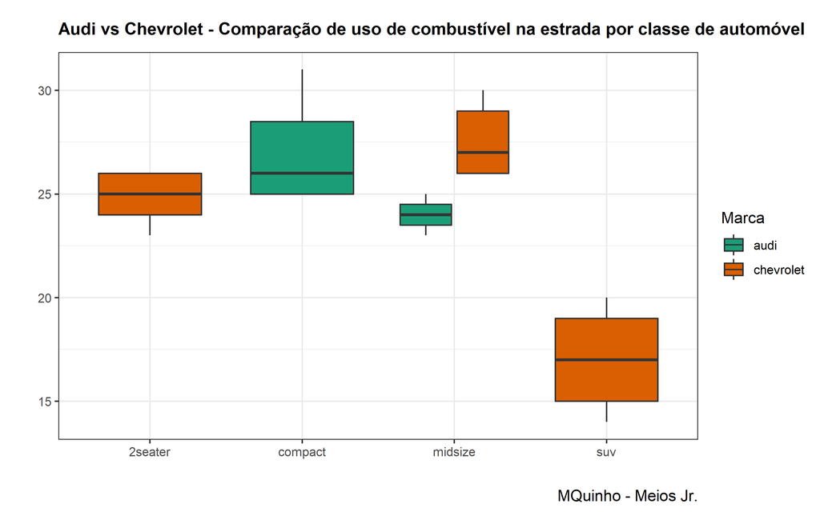

```r
mpg %>%
  filter(manufacturer %in% c('chevrolet', 'audi')) %>%
  ggplot(mapping = aes(x = class,
                       y = hwy,
                       fill = manufacturer)) +
  geom_boxplot() +
  theme_bw() +
  scale_fill_brewer(palette = 'Dark2') +
  labs(title = 'Audi vs Chevrolet - Comparação de uso de combustível na estrada por classe de automóvel',
       y = '',
       x = '',
       fill = 'Marca',
       caption = "MQuinho - Meios Jr.") +
  theme(plot.title = element_text(face = "bold",
                                  margin = margin(10, 0, 10, 0),
                                  size = 12),
        axis.title.x = element_text(margin = margin(t = 5),
                                    size = 12,
                                    face = 'italic'),
        axis.title.y = element_text(margin = margin(r = 10),
                                    size = 12,
                                    face = 'italic'),
        plot.caption = element_text(size = 11))
```

### 3.4. Diagramas de dispersão

[figure not shown]

```r
mpg %>%
  ggplot(mapping = aes(x = cty,
                       y = hwy)) +
  geom_point() +
  theme_bw() +
  scale_fill_brewer(palette = 'Dark2') +
  labs(title = 'Relação entre HWY e CTY',
       y = 'cty',
       x = 'hwy',
       fill = 'Marca',
       caption = "MQuinho - Meios Jr.") +
  theme(plot.title = element_text(face = "bold",
                                  margin = margin(10, 0, 10, 0),
                                  size = 12),
        axis.title.x = element_text(margin = margin(t = 5),
                                    size = 12,
                                    face = 'italic'),
        axis.title.y = element_text(margin = margin(r = 10),
                                    size = 12,
                                    face = 'italic'),
        plot.caption = element_text(size = 11))
```

### 3.5. Gráficos de linha

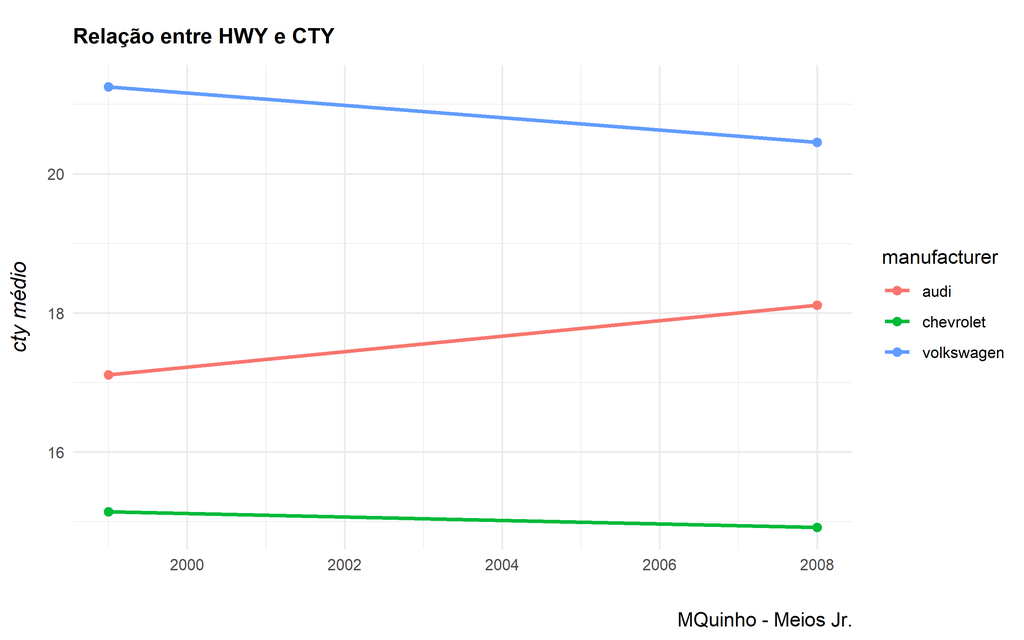

```r
mpg %>%
  filter(manufacturer %in% c('volkswagen', 'chevrolet', 'audi')) %>%
  group_by(year, manufacturer) %>%
  summarise(media_hwy_manuf = mean(cty)) %>%
  ggplot(mapping = aes(x = year, y = media_hwy_manuf, color = manufacturer)) +
  geom_line(size = 1) +
  geom_point(size = 2) +
  theme_minimal() +
  scale_fill_brewer(palette = 'Dark2') +
  labs(title = 'Relação entre HWY e CTY',
       y = 'cty médio',
       x = '',
       fill = 'Marca',
       caption = "MQuinho - Meios Jr.") +
  theme(plot.title = element_text(face = "bold",
                                  margin = margin(10, 0, 10, 0),
                                  size = 12),
        axis.title.x = element_text(margin = margin(t = 5),
                                    size = 12,
                                    face = 'italic'),
        axis.title.y = element_text(margin = margin(r = 10),
                                    size = 12,
                                    face = 'italic'),
        plot.caption = element_text(size = 11))
```

## 4. Tidy data - O conceito

Um dado “tidy” é aquele que se enquadra num formato padronizado, adequado a maior parte dos procedimentos e funções de análise disponíveis no R.

Para estar no formato tidy, o dado deve possuir as seguintes características:

1. Cada variável deve ter a sua respectiva coluna;
2. Cada observação deve ter sua respectiva linha;
3. Cada valor deve ter sua própria célula.


### **4.1. Exemplo de dado Tidy e Não tidy**

" Bancos de dados tidy são todos similares, mas cada banco de dado não tidy é bagunçado à sua maneira" - R for Data Science

```r
# Tidy
table1
```

```
## # A tibble: 6 x 4
##   country      year  cases population
##   <chr>       <int>  <int>      <int>
## 1 Afghanistan  1999    745   19987071
## 2 Afghanistan  2000   2666   20595360
## 3 Brazil       1999  37737  172006362
## 4 Brazil       2000  80488  174504898
## 5 China        1999 212258 1272915272
## 6 China        2000 213766 1280428583
```

```r
# Não tidy
table2
```

```
## # A tibble: 12 x 4
##    country      year type            count
##    <chr>       <int> <chr>           <int>
##  1 Afghanistan  1999 cases             745
##  2 Afghanistan  1999 population   19987071
##  3 Afghanistan  2000 cases            2666
##  4 Afghanistan  2000 population   20595360
##  5 Brazil       1999 cases           37737
##  6 Brazil       1999 population  172006362
##  7 Brazil       2000 cases           80488
##  8 Brazil       2000 population  174504898
##  9 China        1999 cases          212258
## 10 China        1999 population 1272915272
## 11 China        2000 cases          213766
## 12 China        2000 population 1280428583
```

```r
table3
```

```
## # A tibble: 6 x 3
##   country      year rate
## * <chr>       <int> <chr>
## 1 Afghanistan  1999 745/19987071
## 2 Afghanistan  2000 2666/20595360
## 3 Brazil       1999 37737/172006362
## 4 Brazil       2000 80488/174504898
## 5 China        1999 212258/1272915272
## 6 China        2000 213766/1280428583
```

```r
table4a
```

```
## # A tibble: 3 x 3
##   country     `1999` `2000`
## * <chr>        <int>  <int>
## 1 Afghanistan    745   2666
## 2 Brazil       37737  80488
## 3 China       212258 213766
```

```r
table4b
```

```
## # A tibble: 3 x 3
##   country         `1999`     `2000`
## * <chr>            <int>      <int>
## 1 Afghanistan   19987071   20595360
## 2 Brazil       172006362  174504898
## 3 China       1272915272 1280428583
```

### 4.2. Data tidying - Pivoting

Os procedimentos de pivoting (ou pivotagem) são utilizados para lidar com situações em que os valores de uma variável estão espalhados em múltiplas colunas, ou múltiplas colunas contém valores que deveriam estar em uma única variável.

#### 4.2.1. Longer (formato mais longo)

É o procedimento utilizado quando os valores que deveriam estar em células de uma mesma coluna estão espalhados em várias. Trata-se de um formato análogo ao encontrado em tabelas.

```r
table4a %>%
  pivot_longer(cols = c(`1999`, `2000`),
               names_to = 'Ano',
               values_to = 'Casos')
```

```
## # A tibble: 6 x 3
##   country     Ano    Casos
##   <chr>       <chr>  <int>
## 1 Afghanistan 1999     745
## 2 Afghanistan 2000    2666
## 3 Brazil      1999   37737
## 4 Brazil      2000   80488
## 5 China       1999  212258
## 6 China       2000  213766
```

```r
table4b %>%
  pivot_longer(c(`1999`, `2000`),
               names_to = "Ano",
               values_to = "População")
```

```
## # A tibble: 6 x 3
##   country     Ano    População
##   <chr>       <chr>      <int>
## 1 Afghanistan 1999    19987071
## 2 Afghanistan 2000    20595360
## 3 Brazil      1999   172006362
## 4 Brazil      2000   174504898
## 5 China       1999  1272915272
## 6 China       2000  1280428583
```

#### 4.2.2. Wider (formato mais largo)

De maneira oposta ao pivot_longer, trata-se de tornar valores de uma coluna em novas variáveis, reduzindo ou eliminando a repetição de linhas.

```r
table2 %>%
    pivot_wider(names_from = type,
                values_from = count)
```

```
## # A tibble: 6 x 4
##   country      year  cases population
##   <chr>       <int>  <int>      <int>
## 1 Afghanistan  1999    745   19987071
## 2 Afghanistan  2000   2666   20595360
## 3 Brazil       1999  37737  172006362
## 4 Brazil       2000  80488  174504898
## 5 China        1999 212258 1272915272
## 6 China        2000 213766 1280428583
```

### 4.3 Data tidying - Separando e unindo colunas

#### 4.3.1. separate()

```r
# Separate com todos os argumentos possíveis
table3 %>%
  separate(rate,
           into = c('casos', 'população'),
           sep = '/',
           remove = F,
           convert = T)
```

```
## # A tibble: 6 x 5
##   country      year rate               casos  população
##   <chr>       <int> <chr>              <int>      <int>
## 1 Afghanistan  1999 745/19987071         745   19987071
## 2 Afghanistan  2000 2666/20595360       2666   20595360
## 3 Brazil       1999 37737/172006362    37737  172006362
## 4 Brazil       2000 80488/174504898    80488  174504898
## 5 China        1999 212258/1272915272 212258 1272915272
## 6 China        2000 213766/1280428583 213766 1280428583
```

```r
# Separate pela posição
table3_separate <- table3 %>%
  separate(year, into = c('Seculo','Ano'), sep = 2)
```

#### 4.3.2. unite()

```r
table3_separate %>%
  unite(ano_completo, Seculo, Ano, sep = '', remove = F)
```

```
## # A tibble: 6 x 5
##   country     ano_completo Seculo Ano   rate
##   <chr>       <chr>        <chr>  <chr> <chr>
## 1 Afghanistan 1999         19     99    745/19987071
## 2 Afghanistan 2000         20     00    2666/20595360
## 3 Brazil      1999         19     99    37737/172006362
## 4 Brazil      2000         20     00    80488/174504898
## 5 China       1999         19     99    212258/1272915272
## 6 China       2000         20     00    213766/1280428583
```

**Exemplo:** códigos ocupacionais da PNAD.

### 4.4. Data tidying - Trabalhando com strings

https://github.com/rstudio/cheatsheets/blob/main/strings.pdf

#### 4.4.1. Removendo acentuação:

```r
#install.packages('stringi)
library(stringi)

texto_teste <- data.frame(comentario = c('úm texto múítô acêntúadô','um TEXTO MUITO dEsesTruturadO ç'))

# Opção 1:
texto_teste$comentario <- stri_trans_general(texto_teste$comentario,"Latin-ASCII")

# Opção 2:
rm_accent <- function(str,pattern="all") {
   if(!is.character(str))
    str <- as.character(str)

  pattern <- unique(pattern)

  if(any(pattern=="Ç"))
    pattern[pattern=="Ç"] <- "ç"

  symbols <- c(
    acute = "áéíóúÁÉÍÓÚýÝ",
    grave = "àèìòùÀÈÌÒÙ",
    circunflex = "âêîôûÂÊÎÔÛ",
    tilde = "ãõÃÕñÑ",
    umlaut = "äëïöüÄËÏÖÜÿ",
    cedil = "çÇ"
  )

  nudeSymbols <- c(
    acute = "aeiouAEIOUyY",
    grave = "aeiouAEIOU",
    circunflex = "aeiouAEIOU",
    tilde = "aoAOnN",
    umlaut = "aeiouAEIOUy",
    cedil = "cC"
  )

  accentTypes <- c("´","`","^","~","¨","ç")

  if(any(c("all","al","a","todos","t","to","tod","todo")%in%pattern)) # opcao retirar todos
    return(chartr(paste(symbols, collapse=""), paste(nudeSymbols, collapse=""), str))

  for(i in which(accentTypes%in%pattern))
    str <- chartr(symbols[i],nudeSymbols[i], str)

  return(str)
}

# ------------- Aplicações, ufa --------------------------------------
# R Base
texto_teste$comentario <- rm_accent(texto_teste$comentario)

# Tidyverse
texto_teste %>%
  mutate_if(is.character, rm_accent)
```

```
##                        comentario
## 1        um texto muito acentuado
## 2 um TEXTO MUITO dEsesTruturadO c
```

#### 4.4.2. Transformando letras maiúsculas em minúsculas e vice-versa

```r
str_to_lower(texto_teste$comentario)
```

```
## [1] "um texto muito acentuado"        "um texto muito desestruturado c"
```

```r
str_to_upper(texto_teste$comentario)
```

```
## [1] "UM TEXTO MUITO ACENTUADO"        "UM TEXTO MUITO DESESTRUTURADO C"
```

```r
# Maneira tidyverse
texto_teste %>%
  mutate(comentario = str_to_upper(comentario))
```

```
##                        comentario
## 1        UM TEXTO MUITO ACENTUADO
## 2 UM TEXTO MUITO DESESTRUTURADO C
```

```r
fruit[str_order(fruit)]
```

```
##  [1] "apple"             "apricot"           "avocado"
##  [4] "banana"            "bell pepper"       "bilberry"
##  [7] "blackberry"        "blackcurrant"      "blood orange"
## [10] "blueberry"         "boysenberry"       "breadfruit"
## [13] "canary melon"      "cantaloupe"        "cherimoya"
## [16] "cherry"            "chili pepper"      "clementine"
## [19] "cloudberry"        "coconut"           "cranberry"
## [22] "cucumber"          "currant"           "damson"
## [25] "date"              "dragonfruit"       "durian"
## [28] "eggplant"          "elderberry"        "feijoa"
## [31] "fig"               "goji berry"        "gooseberry"
## [34] "grape"             "grapefruit"        "guava"
## [37] "honeydew"          "huckleberry"       "jackfruit"
## [40] "jambul"            "jujube"            "kiwi fruit"
## [43] "kumquat"           "lemon"             "lime"
## [46] "loquat"            "lychee"            "mandarine"
## [49] "mango"             "mulberry"          "nectarine"
## [52] "nut"               "olive"             "orange"
## [55] "pamelo"            "papaya"            "passionfruit"
## [58] "peach"             "pear"              "persimmon"
## [61] "physalis"          "pineapple"         "plum"
## [64] "pomegranate"       "pomelo"            "purple mangosteen"
## [67] "quince"            "raisin"            "rambutan"
## [70] "raspberry"         "redcurrant"        "rock melon"
## [73] "salal berry"       "satsuma"           "star fruit"
## [76] "strawberry"        "tamarillo"         "tangerine"
## [79] "ugli fruit"        "watermelon"
```

```r
str_view_all(sentences, "[aeiou]")
```

[interactive chart not shown]

#### 4.4.3. Colapsando múltiplos espaços em um e eliminando espaços

```r
# ------- Reduzindo espaços do início, no meio e do fim de uma string --------

str_trim_exemplo <- c(' No início desse string tem um espaço, no final também ',
                      'No  meio desse   string tem vários espaços  desnecessários')

str_trim_exemplo_tratado <- str_trim(str_trim_exemplo)
str_trim_exemplo_tratado <- str_squish(str_trim_exemplo)

# Removendo todos os espaços
str_replace_all(str_trim_exemplo, pattern = ' ', replacement = '')
```

```
## [1] "Noiníciodessestringtemumespaço,nofinaltambém"
## [2] "Nomeiodessestringtemváriosespaçosdesnecessários"
```

```r
# ------ Reduzindo o tamanho das strings -------

string_x <- 'um grande string, cheio de palavras'
str_trunc(string_x, 20)
```

```
## [1] "um grande string,..."
```

```r
# Sem o pipe
sentences_trunc <- str_trunc(sentences, 10)

# Com o pipe
sentences_trunc_tidy <- sentences %>%
  str_trunc(width = 20)
```

### 4.5. Mutate em strings

Muitas vezes precisamos utilizar funções de reconhecimento de strings para a recodificação (mutate) de variáveis. É um processo usual na ciência de dados, principalmente ao lidar com dados que foram tabulados à mão.

#### 4.5.1. Funções auxiliares de reconhecimento de padrões textuais:

```r
# Criando um dataframe para trabalho
sentences_df <- as.data.frame(sentences)

sentences_df <- sentences_df %>%
  mutate(id_sentence = seq(1,720)) %>%
  relocate(id_sentence, sentences)

# Detectar um padrão de strings - str_detect()
pencils <- sentences_df %>%
  filter(str_detect(sentences, 'pencil'))

# Detectar um padrão de strings com início ou fim específicos
starts_with_T <- sentences_df %>%
  filter(str_starts(sentences, 'T'))

ends_with_s_ou_d <- sentences_df %>%
  filter(str_ends(sentences, 's\\.|d\\.'))
```

#### 4.5.2. Mutates em strings

Existem funções dedicadas para o procedimento de recodificação de strings, mas em grande parte dos casos, as funções de detecção + o mutate tradicional fazem o trabalho.

```r
words <- stringr::words
words_df <- as.data.frame(words)

words_df <- words_df %>%
  mutate(id_words = seq(1,980)) %>%
  relocate(id_words, words)


# Usando as funções que aprendemos nas recodificações:
words_recode <- words_df %>%
  mutate(contem_we = case_when(str_detect(words, pattern = 'we') ~ 'Contém "we"'),
         comeca_ac = case_when(str_starts(words, pattern = 'ac') ~ 'Começa "ac"'),
         ends_a    = case_when(str_ends(words, pattern = 'a') ~ 'Termina c/ "a"'),
         iniciais  = str_sub(words,1,3),
         as_por_es = str_replace(words, pattern = 'a', replacement = 'e'),
         sem_as    = str_remove(words, pattern = 'a'))
```

## 5. Procedimentos de Join

Os joins são uma das ferramentas mais importantes da Ciência de Dados, pois MUITO frequentemente nos deparamos com dados que compartilham uma mesma coluna de referência, mas que estão em planilhas/tabelas separadas.

### 5.1. Principais tipos de Join

```r
#install.packages('nycflights13')
library(nycflights13)
```

#### 5.1.1. Left Join - O mais importante

O left join é o tipo de join padrão. Ele é utilizado com frequência pois mantém todas as linhas do dataframe X, ainda que não haja correspondência imediata em todos os elementos da coluna chave, compartilhada por X e Y.

```r
#flights
#airlines

# Começamos com um procedimento de filtragem das colunas desejadas
flights2 <- flights %>%
  select(year:day, origin, carrier)

# Join com o nome das companhias aéreas pelo identificador da operadora (carrier)

flights_airlines <- flights2 %>%
  left_join(airlines, by = "carrier")

# DF resultante do join
flights_airlines
```

```
## # A tibble: 336,776 x 6
##     year month   day origin carrier name
##    <int> <int> <int> <chr>  <chr>   <chr>
##  1  2013     1     1 EWR    UA      United Air Lines Inc.
##  2  2013     1     1 LGA    UA      United Air Lines Inc.
##  3  2013     1     1 JFK    AA      American Airlines Inc.
##  4  2013     1     1 JFK    B6      JetBlue Airways
##  5  2013     1     1 LGA    DL      Delta Air Lines Inc.
##  6  2013     1     1 EWR    UA      United Air Lines Inc.
##  7  2013     1     1 EWR    B6      JetBlue Airways
##  8  2013     1     1 LGA    EV      ExpressJet Airlines Inc.
##  9  2013     1     1 JFK    B6      JetBlue Airways
## 10  2013     1     1 LGA    AA      American Airlines Inc.
## # ... with 336,766 more rows
```

#### 5.1.2. Right Join

```r
# DF voos da American Airlines
AA_DL <- airlines %>%
  filter(carrier %in% c('AA', 'DL'))

# Right join no banco flights
AA_DL_flights <- flights %>%
  right_join(AA_DL, by = "carrier")
```

#### 5.1.3. Inner Join

```r
# Banco com os dados de voo de três companhias aéreas
flights_UA_AA_B6 <- flights %>%
  filter(carrier %in% c('AA', 'UA', 'B6'))

# Nomes de cinco companhias aéreas
airlines_exemplo <- airlines %>%
  filter(carrier %in% c('AA', 'UA', 'DL', 'EV', 'WN'))

# Join
flights_innerjoin <- flights_UA_AA_B6 %>%
  inner_join(airlines_exemplo, by = "carrier")

# Checagem
flights_innerjoin %>%
  count(name)
```

```
## # A tibble: 2 x 2
##   name                       n
##   <chr>                  <int>
## 1 American Airlines Inc. 32729
## 2 United Air Lines Inc.  58665
```

#### 5.1.4. Full Join

```r
# Operação de full join
flights_fulljoin <- flights_UA_AA_B6 %>%
  full_join(airlines_exemplo, by = 'carrier')

# Checagem
flights_fulljoin %>%
  count(name)
```

```
## # A tibble: 6 x 2
##   name                         n
##   <chr>                    <int>
## 1 American Airlines Inc.   32729
## 2 Delta Air Lines Inc.         1
## 3 ExpressJet Airlines Inc.     1
## 4 Southwest Airlines Co.       1
## 5 United Air Lines Inc.    58665
## 6 <NA>                     54635
```

## 6. Funções

É bastante comum que precisemos repetir conjuntos de operações iguais para múltiplos vetores/objetos. Na medida em que o código cresce isso se torna um problema, pois para aplicar qualquer alteração que fizermos a um destes objetos a todos os outros, precisaremos reescrever o código para cada um deles. As funções nos ajudam em dois aspectos deste problema:

1. Condensam o conjunto operações em um único argumento (a função), permitindo que modifiquemos os inputs ao invés ter que reescrever o código;
2. Facilitam o debugging, uma vez que uma alteração feita na função mãe altera automaticamente os outputs resultantes de sua utilização.

### 6.1. Estrutura básica

#### 6.1.1. Exemplo com o banco de dados mpg

Vamos criar duas tabelas, cada uma com as médias de cty e hwy e seus respectivos desvios padrão, por marca de carro.

```r
mpg
```

```
## # A tibble: 234 x 11
##    manufacturer model      displ  year   cyl trans drv     cty   hwy fl    class
##    <chr>        <chr>      <dbl> <int> <int> <chr> <chr> <int> <int> <chr> <chr>
##  1 audi         a4           1.8  1999     4 auto~ f        18    29 p     comp~
##  2 audi         a4           1.8  1999     4 manu~ f        21    29 p     comp~
##  3 audi         a4           2    2008     4 manu~ f        20    31 p     comp~
##  4 audi         a4           2    2008     4 auto~ f        21    30 p     comp~
##  5 audi         a4           2.8  1999     6 auto~ f        16    26 p     comp~
##  6 audi         a4           2.8  1999     6 manu~ f        18    26 p     comp~
##  7 audi         a4           3.1  2008     6 auto~ f        18    27 p     comp~
##  8 audi         a4 quattro   1.8  1999     4 manu~ 4        18    26 p     comp~
##  9 audi         a4 quattro   1.8  1999     4 auto~ 4        16    25 p     comp~
## 10 audi         a4 quattro   2    2008     4 manu~ 4        20    28 p     comp~
## # ... with 224 more rows
```

```r
# --------------- Abordagem sem uso de funções -------

# Cálculo de média e desvio para cty por marca
cty_mean <- mpg %>%
  group_by(manufacturer) %>%
  summarise(media_cty = mean(cty),
            sd_cty = mean(cty))

# Cálculo de média e desvio para hwy por marca
hwy_mean <- mpg %>%
  group_by(manufacturer) %>%
  summarise(media_hwy = mean(hwy),
            sd_hwy = mean(hwy))


# --------------- Função ---------------------


build_mean_sd <- function(bd, group, var) {

  bd %>%
    group_by({{group}}) %>%
    summarise(mean = mean({{var}}),
              sd   = sd({{var}}))
  }

hwy_mean2 <- build_mean_sd(bd = mpg, group = manufacturer, var = hwy)
cty_mean2 <- build_mean_sd(mpg, manufacturer, cty)
```

#### 6.1.2. Execução condicional de funções com IF, ELSE IF e ELSE

```r
# if (temp <= 0) {
#   "freezing"
# } else if (temp <= 10) {
#   "cold"
# } else if (temp <= 20) {
#   "cool"
# } else if (temp <= 30) {
#   "warm"
# } else {
#   "hot"
# }
```

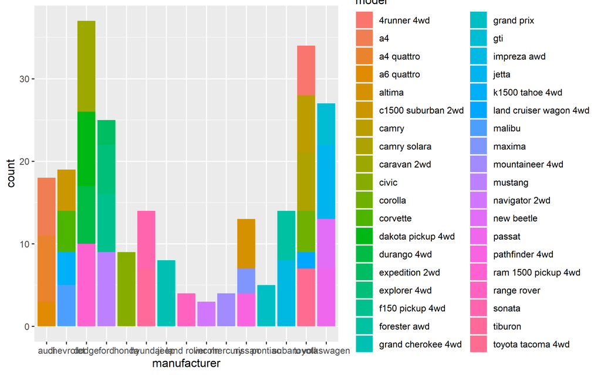

```r
constroi_barras <- function(bd, x, y, fill) {
  if(missing(y)){

    bd %>%
      ggplot2::ggplot(mapping = aes(x = {{x}}, fill = {{fill}})) +
      geom_bar()
  }
  else {

    bd %>%
      ggplot2:: ggplot(mapping = aes(x = {{x}}, y = {{y}}, fill = {{fill}})) +
      geom_col()
  }
}

constroi_barras(bd = mpg, x = manufacturer, fill = model)
```

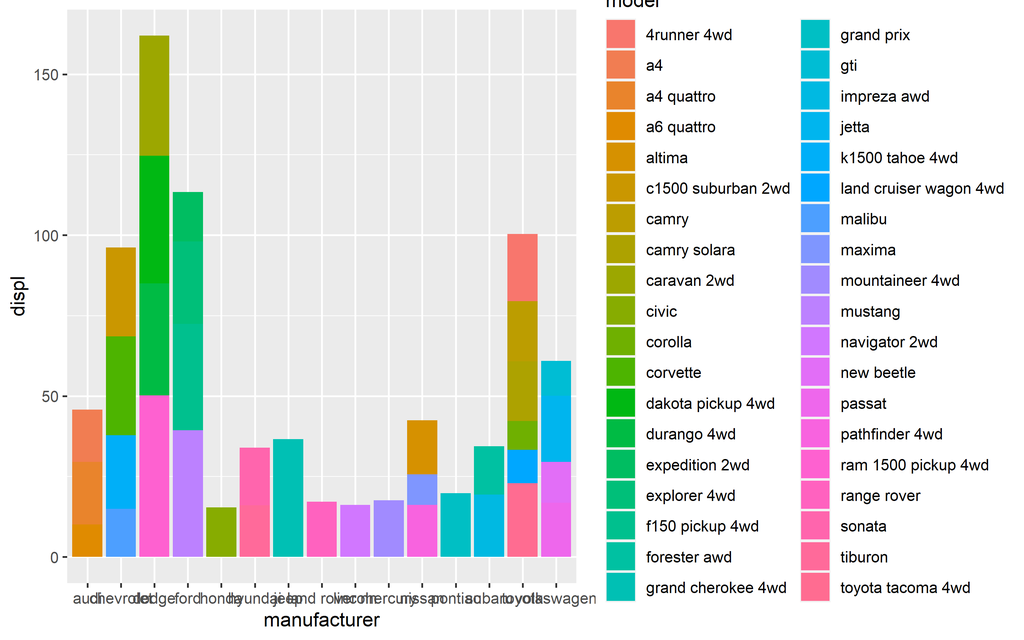

```r
constroi_barras(bd = mpg, x = manufacturer, y = displ, fill = model)
```